# 09 Ordination - Anglerfish

Griffin Patel

2026-04-28

INTERPRETATION #1: What is your scientific question and hypotheses? Do they relate to abundance-unweighted (presence-absence) or abundance-weighted (relative abundance) metrics?

My scientific question is how microbial community composition differs between luminous and non-luminous body regions of deep-sea anglerfishes. The null hypothesis is that luminous body regions do not differ in microbial composition from non-luminous regions. The alternative hypothesis is that luminous body regions have significantly different microbial composition, with an enriched presence of luminescent symbionts and therefore a more distinct community structure. This question is most closely related to abundance-weighted metrics, because the relative abundances of the associated taxa are important for determining whether luminous tissues are dominated by particular symbiotic bacteria. However, abundance-unweighted metrics are still useful for determining whether the overall presence or absence of taxa also differs between tissue groups.

## Goals

1. Load in the data.
2. Evaluate the need to normalize/scale/rarefy the read depths before beta-diversity analysis.
3. Calculate one or more dissimilarity metrics relevant to our study system (*e.g.* Sorensen, Bray-Curtis, abundance-unweighted and abundance-weighted UniFrac).
4. Compare and contrast the dissimilarity metrics and their relevance to the study.
5. Visualize the community data with two unconstrained Ordinations:
   1. **PCoA**: Linear Method. Eigenvalue = how much variation is explained by each axis. Choose to view axis 1, 2, 3, etc. and plot them together.
   2. **NMDS**: Non-linear. Smush multiple Dimensions into 2 or 3 axes. Need to report Stress value (ideally <0.15).
6. Run statistics with functions from the vegan R package:
   1. PERMANOVA with `adonis2()`.
   2. betadispR with `betadisper()` and `permutest()`.

```r
# load phyloseq object
load("data/03_PreProcessing/preprocessed_physeq.RData")

# Intuition check on seq depth
min(sample_sums(preprocessed_physeq))
```

```
## [1] 153
```

```r
# Remove the one outlier with low sequence depth (153 reads)

preprocessed_physeq <-
  preprocessed_physeq %>%
  subset_samples(names != "SRR8438128_R1_filtered.fastq.gz") %>%
  # And remove any ASVs unique to this sample, just in case.
  prune_taxa(taxa_sums(.) > 0, .)

# Check the updated phyloseq object
preprocessed_physeq
```

```
## phyloseq-class experiment-level object
## otu_table()   OTU Table:         [ 8549 taxa and 116 samples ]
## sample_data() Sample Data:       [ 116 samples by 37 sample variables ]
## tax_table()   Taxonomy Table:    [ 8549 taxa by 7 taxonomic ranks ]
```

```r
# Create metadata_df
metadata_df <-
  preprocessed_physeq %>%
  sample_data() %>%
  data.frame()

# Create Metadata_df
metadata_df <-
  preprocessed_physeq %>%
  sample_data() %>%
  data.frame()
```

```r
# calculate read counts per sample
raw_TotalSeqs_df <-
  preprocessed_physeq %>%
  # Calculate the total number of sequences/reads
  sample_sums() %>%
  data.frame()

# Rename the column
colnames(raw_TotalSeqs_df)[1] <- "TotalSeqs"

# add a new column of num_ASVs (RAW, non-noramlized # ASVs)
raw_TotalSeqsASVs_df <-
  raw_TotalSeqs_df %>%
  mutate(num_ASVs = rowSums(otu_table(preprocessed_physeq) > 1))

#View(raw_TotalSeqsASVs_df)

# Plot histogram of seq depth
rawSeq_histogram <-
  raw_TotalSeqsASVs_df %>%
  ggplot(aes(x = TotalSeqs)) +
  geom_histogram(bins = 50) +
  scale_x_continuous() +
  labs(title = "Raw Seq Depth Histogram") +
  theme_bw()

# Plot Seq Depth versus num_ASVs
rawSeq_vs_numASV_plot <-
  raw_TotalSeqsASVs_df %>%
  ggplot(aes(x = num_ASVs, y = TotalSeqs)) +
  geom_point() +
  scale_y_continuous() +
  geom_smooth(method = "lm") +
  labs(title = "Raw Seq Depth vs # ASVs") +
  theme_bw()

# is it significant?
summary(lm(TotalSeqs ~ num_ASVs, data = raw_TotalSeqsASVs_df))
```

```
##
## Call:
## lm(formula = TotalSeqs ~ num_ASVs, data = raw_TotalSeqsASVs_df)
##
## Residuals:
##    Min     1Q Median     3Q    Max
## -54648 -31560   -795  24288 257356
##
## Coefficients:
##             Estimate Std. Error t value Pr(>|t|)
## (Intercept) 56777.56    4592.71  12.363   <2e-16 ***
## num_ASVs      -31.76      21.21  -1.497    0.137
## ---
## Signif. codes:  0 '***' 0.001 '**' 0.01 '*' 0.05 '.' 0.1 ' ' 1
##
## Residual standard error: 39750 on 114 degrees of freedom
## Multiple R-squared:  0.01929,    Adjusted R-squared:  0.01069
## F-statistic: 2.242 on 1 and 114 DF,  p-value: 0.137
```

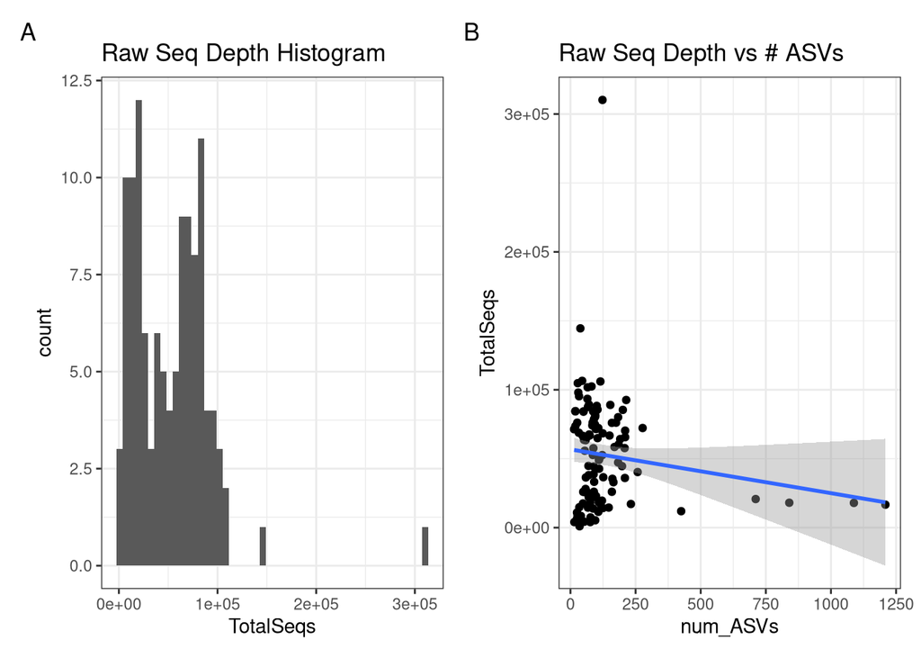

```r
# Put the two plots together.
rawSeq_histogram + rawSeq_vs_numASV_plot +
  plot_annotation(tag_levels = "A")
```

INTERPRETATION #2: Evaluate the raw read count plots above. What did you scale the read counts to in your dataset? Why did you choose that number? What are the potential consequences of this scaling decision for your downstream beta-diversity comparisons?

The raw read count plots show that sequencing depth varies a lot across my samples, with most samples falling well below 100,000 reads but with a few much deeper outliers, including one sample above 300,000 reads. After removing the shallowest outlier sample, I scaled the read counts to the new minimum sequencing depth in the dataset, which was 1,018 reads. I chose that number because it preserves as many samples as possible while still making sequencing depth more comparable across samples for downstream beta-diversity analyses.The raw read depth versus number of ASVs plot also showed that sequencing depth was not significantly associated with the observed number of ASVs (p = 0.137). This suggests that read depth alone is not the main driver of community differences in anglerfish tissues. Even so, scaling is still important because the raw sequencing depth is highly uneven, and without scaling, the deeper samples could negatively impact downstream analysis. A potential consequence of scaling to 1,018 reads is that some rare taxa may be lost or reduced, especially in the more deeply sequenced samples.

```r
min(sample_sums(preprocessed_physeq))
```

```
## [1] 1018
```

```r
# Scale the reads
scaled_physeq <-
  preprocessed_physeq %>%
  scale_reads(round = "matround")

# Look at it
scaled_physeq
```

```
## phyloseq-class experiment-level object
## otu_table()   OTU Table:         [ 4869 taxa and 116 samples ]
## sample_data() Sample Data:       [ 116 samples by 37 sample variables ]
## tax_table()   Taxonomy Table:    [ 4869 taxa by 7 taxonomic ranks ]
```

```r
# Confirm seq read depth of scaled_physeq
scaled_TotalSeqs_df <-
  scaled_physeq %>%
  sample_sums() %>%
  data.frame()

colnames(scaled_TotalSeqs_df)[1] <- "TotalSeqs"

# add a new column of num_ASVs (RAW, non-noramlized # ASVs)
scaled_TotalSeqsASVs_df <-
  scaled_TotalSeqs_df %>%
  mutate(num_ASVs = rowSums(otu_table(scaled_physeq) > 1))

# Plot it!
scaledSeq_histogram <-
  scaled_TotalSeqs_df %>%
  ggplot(aes(x = TotalSeqs)) +
  geom_histogram(bins = 50) +
  labs(title = "Scaled Seq Depth Histogram") +
  scale_x_continuous(limits = c(0, 7500)) +
  theme_bw()

# Scaling always gives us a range!
# MInimum sequences
min(scaled_TotalSeqs_df$TotalSeqs)
```

```
## [1] 914
```

```r
# Total Range
range(scaled_TotalSeqs_df)
```

```
## [1]  914 1034
```

```r
# How many is that range?
range_seqs <- (max(scaled_TotalSeqs_df$TotalSeqs) - min(scaled_TotalSeqs_df$TotalSeqs))
range_seqs
```

```
## [1] 120
```

```r
# And in terms of percent?
range_seqs/max(scaled_TotalSeqs_df$TotalSeqs)
```

```
## [1] 0.1160542
```

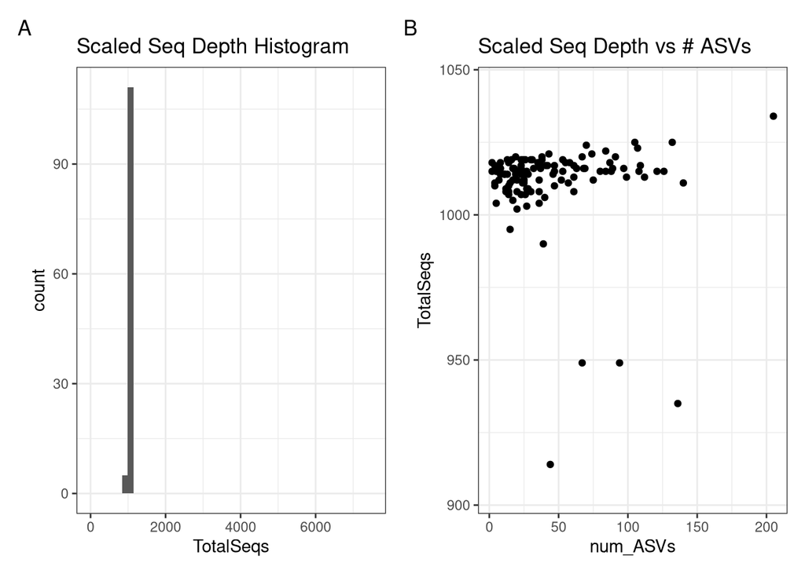

```r
# Set the axis min and max for the next plot
max_y <- max(scaled_TotalSeqs_df$TotalSeqs) + 10
min_y <- min(scaled_TotalSeqs_df$TotalSeqs) - 10

# Now, draw the plot
scaledSeq_vs_numASV_plot <-
  scaled_TotalSeqsASVs_df %>%
  ggplot(aes(x = num_ASVs, y = TotalSeqs)) +
  geom_point() +
  scale_y_continuous(limits = c(min_y, max_y)) +
  #geom_smooth(method = "lm") +
  theme_bw() +
  labs(title = "Scaled Seq Depth vs # ASVs")

# Put the two plots together.
scaledSeq_histogram + scaledSeq_vs_numASV_plot +
  plot_annotation(tag_levels = "A")
```

```r
save(scaled_physeq, file = "data/05_Ordination/scaled_physeq.RData")
```

INTERPRETATION #3: Evaluate the scaled read count plots above. Are the total number of sequences across all of your samples in the same general range? What is the minimum and maximum (i.e., the range) of the sequencing depth? What does this tell you about the relationship between sequencing depth and the observed number of ASVs?

The scaled read count plots show that the total number of sequences across my samples is now tightly centered around about 1,018 reads. This is a major improvement over the raw sequencing depth, which varied widely and included two deeply sequenced outliers. After scaling, the sequencing depth is much more standardized, with a minimum of 914 reads and a maximum of 1034 reads, giving a total range of only 120 reads. This small range shows that the samples are now all in the same general sequencing-depth range. Because of that, the relationship between sequencing depth and the observed number of ASVs has been greatly reduced, so differences in ASV counts should now be much less influenced by uneven sequencing effort. Overall, this suggests that scaling was successful and that my samples are now much more comparable for downstream beta-diversity analyses and ordination.

INTERPRETATION #4: Which dissimilarity metric is most related to your scientific question? Why or why not?

The dissimilarity metric most related to my scientific question is weighted UniFrac, because my question is specifically asking whether luminous and non-luminous anglerfish tissues differ in the abundance of their associated microbial lineages, especially if luminous organs are enriched for a dominant symbiont. Weighted UniFrac is a strong fit because it incorporates both relative abundance and phylogenetic relatedness, which makes it especially useful for asking whether dominant, evolutionarily distinct bacterial lineages differ between tissue groups. Bray-Curtis is also highly relevant and may better capture general abundance trends between tissues, but it does not incorporate phylogenetic information. Because I do not currently have an available phylogenetic tree, Bray-Curtis remains the best non-phylogenetic option. It will still allow me to evaluate whether the abundances of associated taxa differ between luminous and non-luminous tissues, which will allow me to answer my scientific question.

```r
# Sorensen Dissimiliarty
scaled_sorensen_dist <- phyloseq::distance(scaled_physeq, method = "bray", binary = TRUE)

# What does it look like?
class(scaled_sorensen_dist)
```

```
## [1] "dist"
```

```r
str(scaled_sorensen_dist)
```

```
##  'dist' num [1:6670] 0.95 0.856 0.866 0.893 0.853 ...
##  - attr(*, "maxdist")= num 1
##  - attr(*, "Size")= int 116
##  - attr(*, "Labels")= chr [1:116] "SRR8438042_R1_filtered.fastq.gz" "SRR8438043_R1_filtered.fastq.gz" "SRR8438044_R1_filtered.fastq.gz" "SRR8438045_R1_filtered.fastq.gz" ...
##  - attr(*, "Diag")= logi FALSE
##  - attr(*, "Upper")= logi FALSE
##  - attr(*, "method")= chr "binary bray"
##  - attr(*, "call")= language vegdist(x = c(23, 0, 0, 335, 585, 4, 0, 11, 0, 0, 6, 0, 111, 27, 12, 1,  237, 5, 470, 2, 58, 718, 476, 714, 21, 5| __truncated__ ...
```

```r
scaled_bray_dist <- phyloseq::distance(scaled_physeq, method = "bray", binary = FALSE)
```

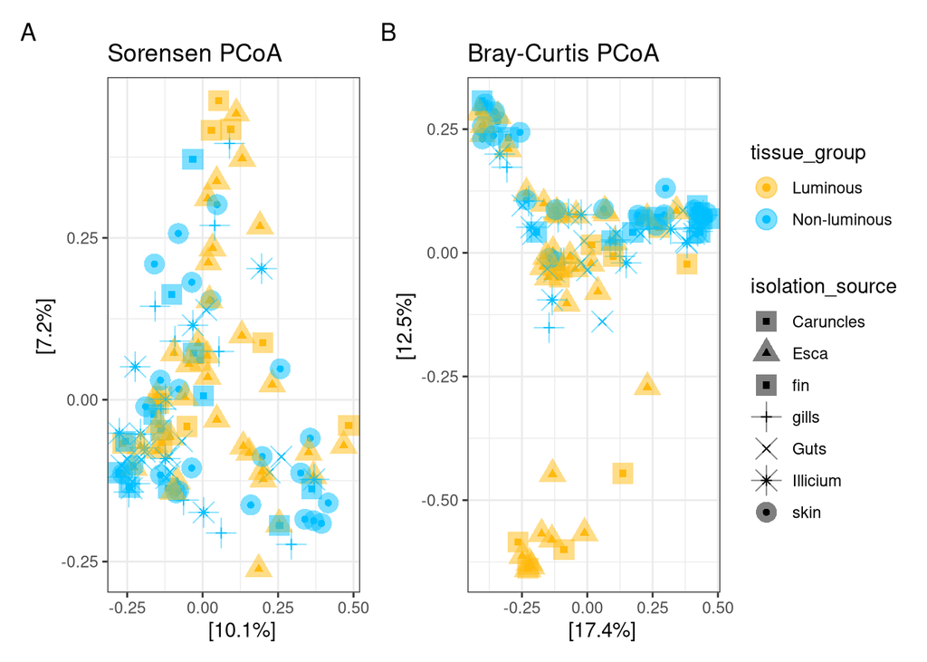

```r
# Make metadata df for plotting

metadata_df <- read.csv("/local/workdir/glp56/Anglerfish_16S/data/metadata/SraRunTable.csv",
                        stringsAsFactors = FALSE)

metadata_df$names <- paste0(metadata_df$Run, "_R1_filtered.fastq.gz")
metadata_df$tissue_group <- ifelse(metadata_df$isolation_source %in% c("Esca", "Caruncles"),
                                   "Luminous",
                                   "Non-luminous")

metadata_df <- metadata_df[match(sample_names(scaled_physeq), metadata_df$names), , drop = FALSE]

rownames(metadata_df) <- metadata_df$names
sample_data(scaled_physeq) <- metadata_df

# Set up style elements

tissue_colors <- c("Luminous" = "darkgoldenrod1",
                   "Non-luminous" = "deepskyblue")

isolation_shapes <- c("Caruncles" = 15,
                      "Esca" = 17,
                      "fin" = 15,
                      "gills" = 3,
                      "Guts" = 4,
                      "Illicium" = 8,
                      "skin" = 16)

## Make PCoA plot

# First, calculate PCoA with Soresen
scaled_soren_pcoa <-
  ordinate(physeq = scaled_physeq,
           method = "PCoA",
           distance = "bray", binary = TRUE)

# Plot it: Sorensen PCoA
sorensen_pcoa_plot <-
  plot_ordination(physeq = scaled_physeq,
                  ordination = scaled_soren_pcoa,
                  color = "tissue_group",
                  shape = "isolation_source",
                  title = "Sorensen PCoA") +
  scale_color_manual(values = tissue_colors) +
  scale_shape_manual(values = isolation_shapes) +
  geom_point(size = 5, alpha = 0.5, aes(color = tissue_group)) +
  theme_bw() +
  theme(legend.position = "right")
# calculate PCoA with Bray-Curtis
scaled_bray_pcoa <-
  ordinate(physeq = scaled_physeq,
           method = "PCoA",
           distance = "bray", binary = FALSE)

# Plot it: Bray-Curtis PCoA
bray_pcoa_plot <-
  plot_ordination(physeq = scaled_physeq,
                  ordination = scaled_bray_pcoa,
                  color = "tissue_group",
                  shape = "isolation_source",
                  title = "Bray-Curtis PCoA") +
  scale_color_manual(values = tissue_colors) +
  scale_shape_manual(values = isolation_shapes) +
  geom_point(size = 5, alpha = 0.5, aes(color = tissue_group)) +
  theme_bw() +
  theme(legend.position = "right")

# Show the plots
sorensen_pcoa_plot + bray_pcoa_plot +
  plot_layout(guides = "collect") +
  plot_annotation(tag_levels = "A")
```

INTERPRETATION #5: Plot your data using a PCoA. Interpret what you can conclude from the PCoA.

The PCoA plots suggest that microbial community composition differs between luminous and non-luminous anglerfish tissues, although the strength of that pattern depends on the dissimilarity metric used. In the Sorensen PCoA, which is based on presence and absence, the two tissue groups overlap substantially, suggesting that many taxa may be shared between luminous and non-luminous tissues. This makes sense, since there are likely common bacteria associated with many parts of the anglerfish. In contrast, the Bray-Curtis PCoA shows clearer structure between the two tissue groups, with luminous samples forming more of a cluster toward the left and lower portions of the plot, although there is still some overlap elsewhere. This suggests that abundance differences are more important than simple presence or absence in distinguishing these tissue-associated microbial communities. Because there is a small clustered luminous group in the Bray-Curtis PCoA, this supports the idea that luminescent symbionts are present in higher abundance in luminous organs. This fits my scientific question, because enrichment of dominant bacterial symbionts in luminous organs is exactly what I am looking for. Overall, Bray-Curtis appears to capture the biologically relevant differences more clearly than Sorensen, suggesting that abundance-weighted community shifts are a major feature of these anglerfish tissue microbiomes.

```r
## SORENSEN
scaled_soren_nmds <-
  ordinate(physeq = scaled_physeq,
         method = "NMDS",
         distance = "bray", binary = TRUE)
```

```
## Square root transformation
## Wisconsin double standardization
## *** Best solution was not repeated -- monoMDS stopping criteria:
##      2: no. of iterations >= maxit
##     18: stress ratio > sratmax
```

```r
# Plot it!
sorensen_nmds_plot <-
  plot_ordination(physeq = scaled_physeq,
                ordination = scaled_soren_nmds,
                color = "tissue_group",
                shape = "isolation_source",
                title = "Sorensen NMDS") +
  scale_color_manual(values = tissue_colors) +
  scale_shape_manual(values = isolation_shapes) +
  geom_point(size = 5, alpha = 0.5, aes(color = tissue_group)) +
  theme_bw() +
  theme(legend.position = "right")

### Bray-Curtis
# Second, calculate NMDS with Bray-Curtis
scaled_bray_nmds <-
  ordinate(physeq = scaled_physeq,
         method = "NMDS",
         distance = "bray", binary = FALSE)
```

```
## Square root transformation
## Wisconsin double standardization
## *** Best solution repeated 1 times
```

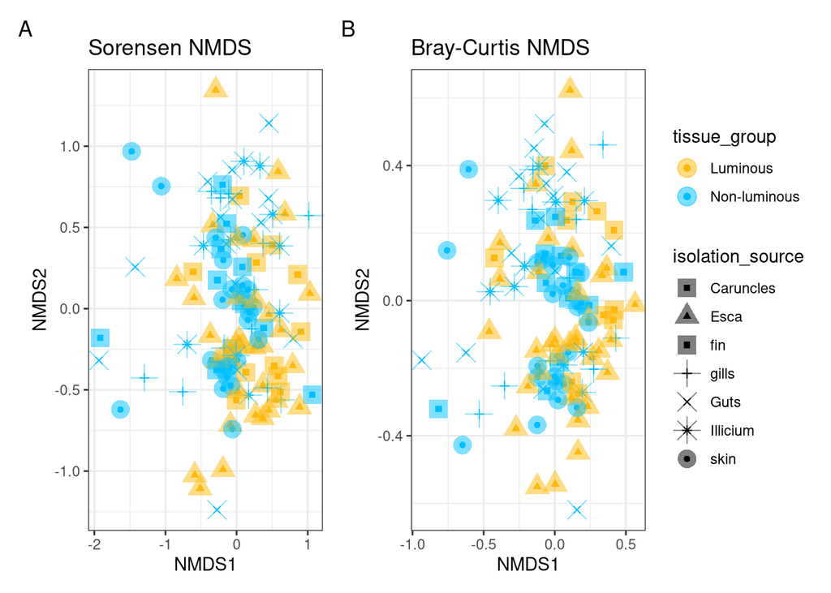

```r
# Plot it: Bray-Curtis NMDS
bray_nmds_plot <-
  plot_ordination(physeq = scaled_physeq,
                ordination = scaled_bray_nmds,
                color = "tissue_group",
                shape = "isolation_source",
                title = "Bray-Curtis NMDS") +
  scale_color_manual(values = tissue_colors) +
  scale_shape_manual(values = isolation_shapes) +
  geom_point(size = 5, alpha = 0.5, aes(color = tissue_group)) +
  theme_bw() +
  theme(legend.position = "right")

# Show the plots
sorensen_nmds_plot + bray_nmds_plot +
  plot_layout(guides = "collect") +
  plot_annotation(tag_levels = "A")
```

INTERPRETATION #6: Plot your data using NMDS and interpret the results. How does the NMDS compare to the PCoA you generated in Interpretation #5? Do the two ordination methods tell a consistent story, or do you notice any differences in how the samples are arranged? Make sure to report the stress value and comment on whether it is acceptable.

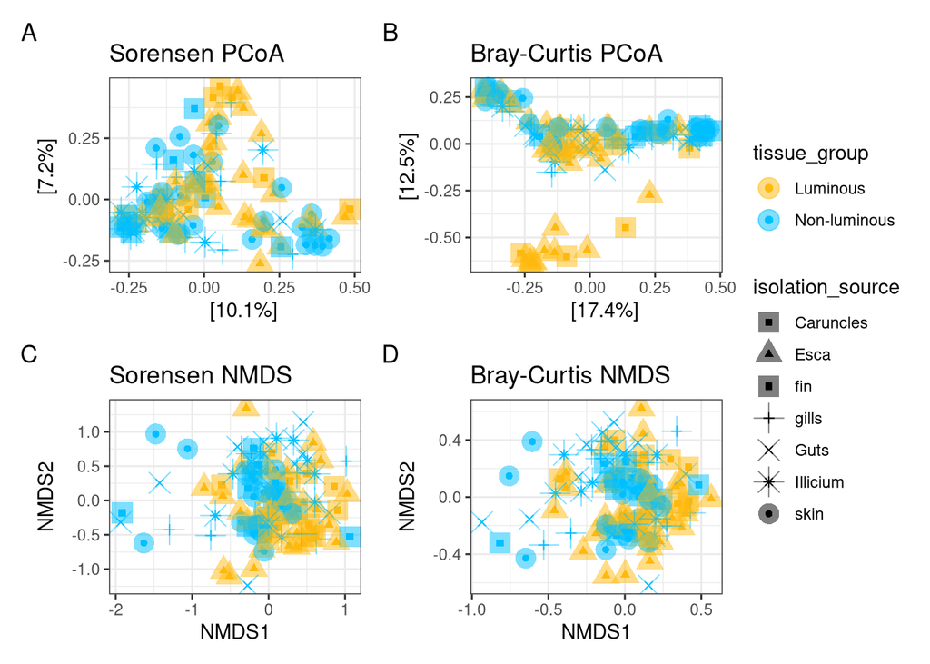

```r
sorensen_pcoa_plot + bray_pcoa_plot +
sorensen_nmds_plot + bray_nmds_plot +
  plot_layout(guides = "collect") +
  plot_annotation(tag_levels = "A")
```

INTERPRETATION #7: Plot both the PCoA and NMDS together. Which of the two ordination methods best represents your data and why? Consider the strengths and limitations of each method. For example, the variance explained by each PCoA axis versus the stress value of the NMDS could be used to justify your choice. Do both methods support the same biological conclusions?

```r
# Bray-Curtis PERMANOVA
bray_tissue_adonis <- adonis2(scaled_bray_dist ~ tissue_group,
                              data = metadata_df,
                              by = "terms")
bray_tissue_adonis
```

```
## Permutation test for adonis under reduced model
## Terms added sequentially (first to last)
## Permutation: free
## Number of permutations: 999
##
## adonis2(formula = scaled_bray_dist ~ tissue_group, data = metadata_df, by = "terms")
##               Df SumOfSqs     R2      F Pr(>F)
## tissue_group   1    1.963 0.0432 5.1477  0.001 ***
## Residual     114   43.482 0.9568
## Total        115   45.446 1.0000
## ---
## Signif. codes:  0 '***' 0.001 '**' 0.01 '*' 0.05 '.' 0.1 ' ' 1
```

```r
# Bray-Curtis dispersion test
dispr_bray_tissue <- betadisper(scaled_bray_dist, metadata_df$tissue_group)

dispr_bray_tissue
```

```
##
##  Homogeneity of multivariate dispersions
##
## Call: betadisper(d = scaled_bray_dist, group =
## metadata_df$tissue_group)
##
## No. of Positive Eigenvalues: 82
## No. of Negative Eigenvalues: 33
##
## Average distance to median:
##     Luminous Non-luminous
##       0.6177       0.5962
##
## Eigenvalues for PCoA axes:
## (Showing 8 of 115 eigenvalues)
## PCoA1 PCoA2 PCoA3 PCoA4 PCoA5 PCoA6 PCoA7 PCoA8
## 7.916 5.670 4.516 2.939 2.339 2.131 1.897 1.584
```

```r
permutest(dispr_bray_tissue)
```

```
##
## Permutation test for homogeneity of multivariate dispersions
## Permutation: free
## Number of permutations: 999
##
## Response: Distances
##            Df  Sum Sq  Mean Sq      F N.Perm Pr(>F)
## Groups      1 0.01279 0.012789 1.0985    999  0.307
## Residuals 114 1.32719 0.011642
```

INTERPRETATION #8: Using the above example to guide you, please run the appropriate PERMANOVA for your scientific question and interpret the results. If you have more than one variable of interest, please make sure to run your model in at least two different term orders and comment on whether the R-squared value changes between models. If so, what does this tell you about whether your variables are independent of one another or co-varying? What biological conclusion can you draw from your PERMANOVA results, and do you accept or reject your hypothesis?

For my scientific question, the most appropriate PERMANOVA used Bray-Curtis dissimilarity with tissue group as the predictor, because I am primarily looking at the abundance-weighted differences between luminous and non-luminous anglerfish tissues. The PERMANOVA result was significant (p = 0.001), which means that tissue group is associated with a significant difference in microbial community composition. The R-squared value was 0.0432, meaning tissue group explained about 4.3% of the total variation in abundance-weighted community structure. This is not a huge amount of variation, but because the symbiont would only make up part of the associated microbiome, I think this makes logical sense. I only used one variable of interest in this model, so running multiple term orders was not necessary here. Biologically, this suggests that luminous and non-luminous tissues differ in the relative abundances of their associated microbes, which fits my scientific question and supports the idea that luminous tissues may be enriched for particular bacterial symbionts. Based on this result, I reject the null hypothesis and support the alternative hypothesis.

INTERPRETATION #9: Using the above example to guide you, run the appropriate betadisper() and permutest() for your scientific question and interpret the results. What biological conclusion can you draw from your dispersion analysis?

INTERPRETATION #10: Taking into account both the betadisper()/permutest() and the PERMANOVA (adonis2()) test that you ran, what biological conclusion can you draw regarding your data?

```r
# Take the time now that we are at the end of the script
end_time <- Sys.time()
end_time
```

```
## [1] "2026-04-28 23:37:49 EDT"
```

```r
# Echo the elapsed time
elapsed_time <- round((end_time - start_time), 3)
elapsed_time
```

```
## Time difference of 14.841 secs
```